# Assignment 2: Undercooked

Introduction to Software Engineering (CSSE 1001)  
**Due: 22 May 2026, 15:00 GMT+10**

Author

Course Staff (Communal Document)

Published

May 15, 2026

## Changelog

- 24/04/26:
  - Initial Release.
- 29/04/26:
  - Added missing row for command `q` in Table 2.
  - Fixed wrong method names in `support.py`.
  - Removed circular import from `display.py`.
  - Typo (singular)
  - **`support.py` and `display.py` have been updated. please re-download `a2.zip` if you downloaded it prior to 12:30 29/04/26**
- 06/05/26:
  - Fixed typo in UML diagram.
  - Corrected Patron `__init__` description.

## Introduction

[Overcooked](https://ghosttowngames.com/game/overcooked/) is a chaotic time management game developed by Ghost Town Games in 2016. In this assignment, you will not be implementing Overcooked. Instead, you will be implementing a *heavily* simplified, text based version of Overcooked called Undercooked. In Undercooked, you own and are the sole employee of a world renowned sandwich kitchen. Unfortunately your kitchen’s fame has outgrown your capacity and you must work to combine ingredients and serve all your customers before any get angry, all the while only having a single pair of hands! Note that this task sheet takes precedence in the event it describes differences in gameplay from the original *Overcooked*.

## Getting Started

Download `a2.zip` from Blackboard. This archive contains the necessary files to start your assignment. Once extracted, the `a2.zip` archive will provide the following files:

- `a2.py`: *This is the only file you will submit* and is where you write your code. *Do not* make changes to any other files.
- `support.py`: *Do not modify or submit this file*, it contains pre-defined constants to use in your assignment. In addition to these, you are encouraged to create your own constants in `a2.py` where possible.
- `display.py`: *Do not modify or submit this file*, it contains additional supporting code for displaying your assignment in a visually appealing manner. You should not need to read and understand the contents of this file.
- `gameplay/`: This folder contains a number of example outputs generated by playing the game using a fully-functional completed solution to this assignment. The purpose of the files in this folder is to help you understand how the game works, and how output should be formatted.
- `levels/` This folder contains a small collection of files used to initialize games of *Undercooked*. In addition to these, you are encouraged to create your own files to help test your implementation where possible.

If you also wish to download this task sheet you must first click `View Fullscreen` at the top of the page. This will open the task sheet in a new browser tab. On this tab, use `Ctrl-P` to print the page, and select `Save to PDF` as the output location. The print button on Blackboard only captures the first two or so pages of this sheet (a limitation of Blackboard beyond our control).

**Caution**

The task sheet may be modified throughout the course of the assignment as issues are identified. These updates will appear online, but will **not** be reflected in a previously downloaded copy. Please regularly check the changelog **online** to ensure you are working with the most up to date version of the task sheet.

## Gameplay

This section provides a high-level overview of gameplay, and is intended to provide you with an idea of the behaviour of a fully completed assignment. Where interactions are not explicitly mentioned in this section, please see the Implementation section.

**Important**

Do not simply implement the behaviour described here using your own structure; you *must* implement the individual functions, classes, and methods described in the Implementation section. Inputs and outputs must match *exactly* what is expected. Refer to the Implementation section, the given examples, and the provided Gradescope tests for clarification on required prompts and outputs.

The game revolves around a rectangular *Kitchen* that is constructed out of uniformly sized *tiles*. Each tile represents a *position* on the board (kitchen). The player is an entity that can occupy one position on the board at any given time. Tiles can either be *blocking* or not blocking, with the player unable to occupy blocking tiles.

Each tile on the board, as well as the player, can hold *food items*. The player may *pick up* the food item being held by the tile they are currently located on. This action removes the food item from the tile and moves it to being held by the player. Similarly, the player may *put down* the food item they are currently holding. This removes the food item from the player and moves it to be being held by the tile they are currently located on. The player and each tile may hold at most one food item at any given time. If the player attempts to pick up or put down an item such that more than one item would be held in the same place, the action fails and nothing happens.

There are three types of special tile in an Undercooked kitchen. *Spawners* tiles periodically *spawn* food items. They go from holding no food item to holding a food item without player input. *Combiners* are used to merge two food items into a single new food item based on a fixed set of recipes. If the player attempts to place a food item on a combiner containing a food item with a compatible recipe, both food items are removed and the combiner becomes holding the resulting new food item. Finally, *Patrons* are tiles representing customers. Patrons possess both an *order* and a *patience*. A customer’s order represents the type of food item they desire, and their patience is a number that progressively lowers as gameplay progresses. A Patron is *satisfied*, if at any point in time they have had a food item matching their order placed on them. A patron is *angry* if their patience is not greater than 0 and they are not satisfied. The objective of Undercooked is to satisfy all patrons before any become angry.

Undercooked revolves around the concept of turns. Each turn, the player may wait (do nothing); move 1 position up, down, left, or right; or pick up or put down a Food Item. Each time the player performs one of these actions, the number of turns advances by one. Spawners and Patrons are both *timed tiles*. Timed tiles possess an *interval* and an ongoing *timer*. Every time the number of turns advances by one, all timed tiles decrease their timer by one. When a timed tile’s timer reaches zero, the tile takes an action corresponding to Table 1, and then resets its timer to its interval.

Table 1: Actions performed by timed tiles whenever their timer reaches 0. After performing this action, timers are reset to their interval.

| Timed Tile | Action when timer hits zero |
| --- | --- |
| Spawner | If tile is not holding a food item, spawn food item and become holding it. Otherwise do nothing. |
| Patron | Reduce patience by one. |

The game ends when one of the following occurs:

- The player wins, when all patrons in the kitchen are satisfied.
- The player loses, when a patron becomes angry.

After starting a game of Undercooked, the initial game state is printed to the screen, and the following game loop then occurs:

1. The player is prompted to enter a command using `CMD_PROMPT` from `support.py`. Valid commands are given in Table 2.
2. If the player entered a valid command, an action is attempted as described in Table 2.
3. If an action was not successfully completed, `INVALID_MSG` from `support.py` is printed.
4. The display is updated by printing the current game state to the screen.
5. If the game is not over, gameplay returns to step 1. Otherwise gameplay advances to step 6.
6. Either `WIN_MSG` or `LOSE_MSG` from `support.py` is printed to the screen informing the player that they won or lost the game as appropriate.
7. The program terminates gracefully.

Table 2: Valid commands and the actions that should be taken. Commands are case insensitive. If the command entered by the user does not exactly match one of the commands in this table (case insensitive), then no action should be taken.

| Command | Action to take |
| --- | --- |
| `w` | The player attempts to move up one position. If successful advance the number of turns by 1. |
| `a` | The player attempts to move left one position. If successful advance the number of turns by 1. |
| `s` | The player attempts to move down one position. If successful advance the number of turns by 1. |
| `d` | The player attempts to move right one position. If successful advance the number of turns by 1. |
| `e` | If the player is holding no food item, they attempt to pick up a food item. Otherwise, they attempt to put down a food item. If successful advance the number of turns by 1. |
| `x` | Advance the number of turns by 1. |
| `q` | Gameplay advances immediately to step 7, skipping steps 3-6. |
| `save [F]`, where `[F]` is a filepath | Save current game state to `[F]`. |
| `load [F]`, where `[F]` is a filepath | If `[F]` exists, replace current game state with that contained in `[F]`. Otherwise print `NO_FILE_MESSAGE` from `support.py` |

## Implementation

**Important**

You are **not** permitted to add any additional import statements to `a2.py`. Doing so will result in a deduction of up to 100% of your mark. You must not modify or remove the import statements already provided to you in `a2.py`. Removing or modifying these existing import statements may result in your code not functioning, and may result in a deduction of up to 100% of your mark.

### Required Classes and Methods

This section outlines the classes and methods you are **required** to implement in `a2.py`. Your program must operate *exactly* as specified. In particular, your program’s output must match *exactly* with the expected output. Your program will be marked automatically so minor differences in output (such as whitespace or casing) *will* cause tests to fail resulting in *zero marks* for that test.

You will be following the Apple Model-View-Controller design pattern when implementing this assignment. You have been provided the view component, and are required to implement a number of classes in order to complete the Model and Controller components.

The class diagram in Figure 1 provides an overview of all of the classes you must implement in your assignment, and the basic relationships between them. The details of these classes and their methods are described in depth later in this section. Within Figure 1:

- Orange classes are those provided to you in the supporting files.
- Green classes are abstract classes (superclasses). However, you are not required to enforce the abstract nature of the green classes in their implementation. The purpose of this distinction is to indicate to you that you should only ever instantiate the blue classes in your program (though you should instantiate the green classes to test them before beginning work on their subclasses).
- Blue classes are concrete classes (subclasses).
- Solid arrows indicate inheritance (i.e. the “is-a” relationship).
- Dotted arrows indicate composition (i.e. the “has-a” relationship). An arrow marked with 1-1 denotes that each instance of the class at the base of the arrow contains exactly one instance of the class at the head of the arrow. An arrow marked with 1-N denotes that each instance of the class at the base of the arrow may contain many instances of the class at the head of the arrow.

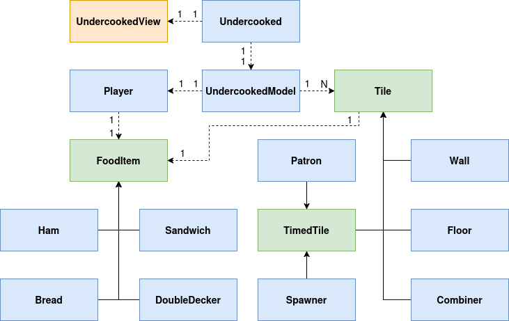

Figure 1: Basic UML diagram for the classes in assignment 2.

**Note**

You are awarded marks for the number of tests passed by your classes when they are tested *independently* of one another. Thus an incomplete assignment with *some* working classes may well be awarded more marks than a complete assignment with faulty classes.

Each class is accompanied with some examples for usage to help you *start* your own testing. You should also test your methods with other values to ensure they operate according to the descriptions.

The rest of this section describes what you must implement in `a2.py` in detail. You should complete the model section before attempting the controller section, ensuring that everything you implement is tested thoroughly, operating correctly, and passes all relevant Gradescope tests. You will not be able to earn marks for the controller section until you have passed all Gradescope tests for the model section.

### Model

The following are the classes and methods you are required to implement as part of the model. You should develop the classes in the order in which they are described in this section and test each one (including on Gradescope) before moving on to the next class. Functionality marks are awarded for each class (and each method) that work correctly. You will likely do very poorly if you submit an attempt at every class, where no classes work according to the description. Some classes require significantly more time to implement than others. The marks allocated to each class are not necessarily an indication of their difficulty or the time required to complete them. You are allowed (and encouraged) to write additional helper methods for any class to help break up long methods, but these helper methods MUST be private (i.e. they must be named with a leading underscore).

#### Task 1 `FoodItem()`

`FoodItem` is an abstract class from which all instantiated types of food inherit. This class provides default food item behavior, which can be inherited or overridden by specific types of food. All food items are represented by a single character identifier, and possess a fixed set of valid recipes. Recipes are depicted using a dictionary, where keys are the single character identifier of food that this food item can be combined with, and values are the single character identifier of the resulting food item.

Abstract food items are represented by the symbol `F` and have no valid recipes.

`FoodItem` must implement the following methods:

- `__init__(self)`  
  Instantiate a new food item.
- `__str__(self) -> str`  
  Returns the identifier that represents this tile.
- `__repr__(self) -> str`  
  Returns a string which could be copied and pasted into a REPL to construct a new instance identical to self.
- `recipes(self) -> dict[str, str]`  
  Returns the valid recipes for this food item.

**Tip**

You may inherit the default `__init__` method if you do not require it.

Example:

```python
>>> yummy = FoodItem()
>>> yummy
```

```
FoodItem()
```

```python
>>> str(yummy)
```

```
'F'
```

```python
>>> yummy.recipes()
```

```
{}
```

#### Task 2 `Ham(FoodItem)`

Extraordinarily versatile sandwich filling. Ham is represented by the symbol `H` and can be combined with bread to produce a sandwich.

Example:

```python
>>> yummy = Ham()
>>> yummy
```

```
Ham()
```

```python
>>> str(yummy)
```

```
'H'
```

```python
>>> yummy.recipes()
```

```
{'B': 'S'}
```

#### Task 3 `Bread(FoodItem)`

The fundamental basis of any sandwich worth mentioning. Bread is represented by the symbol `B`. Bread can be combined with ham to produce a sandwich, but can also be combined with a sandwich to produce a double decker.

Example:

```python
>>> yummy = Bread()
>>> yummy
```

```
Bread()
```

```python
>>> str(yummy)
```

```
'B'
```

```python
>>> yummy.recipes()
```

```
{'H': 'S', 'S': 'D'}
```

#### Task 4 `Sandwich(FoodItem)`

Australia’s favourite sandwich. A sandwich is represented by the symbol `S` and can be combined with bread to produce a double decker.

Example:

```python
>>> yummy = Sandwich()
>>> yummy
```

```
Sandwich()
```

```python
>>> str(yummy)
```

```
'S'
```

```python
>>> yummy.recipes()
```

```
{'B': 'D'}
```

#### Task 5 `DoubleDecker(FoodItem)`

The coveted double decker sandwich. Overnight global sensation after personal recommendation by Terri Irwin. The double decker is represented by the symbol `D` and embodies cullinary perfection (and as such has no valid recipes).

Example:

```python
>>> yummy = DoubleDecker()
>>> yummy
```

```
DoubleDecker()
```

```python
>>> str(yummy)
```

```
'D'
```

```python
>>> yummy.recipes()
```

```
{}
```

#### Task 6 `Tile()`

`Tile` is an abstract class from which all instantiated types of tile inherit. This class provides default tile behavior, which can be inherited or overridden by specific types of tile. All tiles are represented by a single character identifier, and can either be blocking, or not blocking. Any given tile may also hold a single food item. Food cannot be added to a tile if it is currently holding a food item.

Abstract tiles are not blocking, and are represented by the symbol `T`.

`Tile` must implement the following methods:

- `__init__(self, held: FoodItem | None)`  
  Instantiate a new tile holding the given food item, or holding no food item if `held` is `None`.
- `__str__(self) -> str`  
  Returns the identifier that represents this tile if it is holding no food item. Otherwise returns the identifier that represents the food item it is holding.
- `__repr__(self) -> str`  
  Returns a string which could be copied and pasted into a REPL to construct a new instance identical to self.
- `get_type(self) -> str`  
  Returns the identifier that represents this tile.
- `is_blocking(self) -> bool`  
  Returns if this tile is blocking or not.
- `check_food(self) -> FoodItem | None`  
  Returns the food item this tile is holding, or `None` if it is not holding a food item.
- `add_food(self, food: FoodItem) -> bool`  
  Attempts to add the given food item as this tile’s held food. Returns True if (and only if) a food item was added to the tile.
- `remove_food(self) -> FoodItem | None`  
  Removes and returns the food item this tile is holding, or returns `None` if it is not holding a food item.

Example:

```python
>>> tile = Tile(None)
>>> tile
```

```
Tile(None)
```

```python
>>> str(tile)
```

```
'T'
```

```python
>>> tile = Tile(Ham())
>>> tile
```

```
Tile(Ham())
```

```python
>>> str(tile)
```

```
'H'
```

```python
>>> tile.get_type()
```

```
'T'
```

```python
>>> tile.is_blocking()
```

```
False
```

```python
>>> tile.check_food()
```

```
Ham()
```

```python
>>> tile.add_food(Bread())
```

```
False
```

```python
>>> tile.check_food()
```

```
Ham()
```

```python
>>> tile.remove_food()
```

```
Ham()
```

```python
>>> tile.check_food()
```

```python
>>> tile.remove_food()
```

```python
>>> tile.add_food(Bread())
```

```
True
```

```python
>>> tile.check_food()
```

```
Bread()
```

#### Task 7 `Floor(Tile)`

Example:

```python
>>> tile = Floor(None)
>>> tile
```

```
Floor(None)
```

```python
>>> str(tile)
```

```
' '
```

```python
>>> tile.is_blocking()
```

```
False
```

```python
>>> tile.get_type()
```

```
' '
```

#### Task 8 `Wall(Tile)`

`Wall` is a blocking tile representing impassable barriers. Wall tiles are represented by the symbol `W`.

Example:

```python
>>> tile = Wall(None)
>>> tile
```

```
Wall(None)
```

```python
>>> str(tile)
```

```
'W'
```

```python
>>> tile.is_blocking()
```

```
True
```

```python
>>> tile.get_type()
```

```
'W'
```

#### Task 9 `Combiner(Tile)`

`Combiner` is a non-blocking tile that represents a workbench where you can combine two food items into a new one. It is where sandwich dreams become reality. Combiner tiles are represented by the symbol `C`.

When adding a food to a combiner tile already holding food, it does not automatically fail. Instead, the recipes of the held food item are checked and if the incoming food is a valid recipe input, the current held food is removed from the tile and the corresponding recipe output is added in its stead.

Example:

```python
>>> food = Ham()
>>> tile = Combiner(food)
>>> tile
```

```
Combiner(Ham())
```

```python
>>> str(tile)
```

```
'H'
```

```python
>>> tile.is_blocking()
```

```
False
```

```python
>>> food.recipes()
```

```
{'B': 'S'}
```

```python
>>> tile.add_food(DoubleDecker())
```

```
False
```

```python
>>> tile.check_food()
```

```
Ham()
```

```python
>>> tile.add_food(Bread())
```

```
True
```

```python
>>> tile.check_food()
```

```
Sandwich()
```

#### Task 10 `TimedTile(Tile)`

`TimedTile` is an abstract class from which all instantiated types of timed tile inherit. This class provides default timed tile behavior, which can be inherited or overridden by specific types of timed tile. Timed tiles are special tiles that possess an internal timer, and a fixed interval. A timed tile’s timer gradually decreases until it hits zero. When a timed tile’s timer reaches zero, it executes an event and then resets its timer to its interval.

Abstract timed tiles are not blocking, are represented by the symbol `I`, and do nothing when their event is executed.

To support this extended functionality, the `__init__` method of `TimedTile` takes in two additional arguments. In addition to the `Tile` methods that must be supported, `TimedTile` must implement the following methods:

- `__init__(self, held: FoodItem | None, interval: int, remaining: int)`  
  Instantiate a new timed tile with the given interval, and the specified amount remaining on the current timer.
- `event(self)`  
  Execute this tile’s event.
- `get_timer(self) -> int`  
  Returns how much is remaining on this tile’s current timer.
- `get_interval(self) -> int`  
  Returns this tile’s interval.
- `tick(self)`  
  Decrements this tile’s timer by one. Executes this tile’s event and resets its timer if relevant.

**Tip**

The `event` method of the `TimedTile` class will do nothing but pass. This behavior will be overridden by subclasses.

Example:

```python
>>> tile = TimedTile(None, 3, 2)
>>> tile
```

```
TimedTile(None, 3, 2)
```

```python
>>> str(tile)
```

```
'I'
```

```python
>>> tile.get_type()
```

```
'I'
```

```python
>>> tile.is_blocking()
```

```
False
```

```python
>>> tile.event() # Does Nothing
```

```python
>>> tile.get_timer()
```

```
2
```

```python
>>> tile.get_interval()
```

```
3
```

```python
>>> tile.tick()
```

```python
>>> tile.get_timer()
```

```
1
```

```python
>>> tile.tick() # Timer hits zero -> event executed + timer reset
```

```python
>>> tile.get_timer()
```

```
3
```

```python
>>> tile.tick()
```

```python
>>> tile.get_timer()
```

```
2
```

#### Task 11 `Spawner(TimedTile)`

A `Spawner` is a magical tile that summons food items out of thin air. A bonus quarter of a mark (rounded down to the nearest whole) is available to students who can demonstrate to course staff a fully functional construction of this concept in real life. Spawner tiles have a fixed food item type, and if they are not holding any food item when their event is executed, they spawn an instance of this predetermined food item and become holding it. Spawners are represented by the symbol `E`.

To support this extended functionality, the `__init__` method of `Spawner` takes in an additional argument. In addition to the `TimedTile` methods that must be supported, `Spawner` must implement the following methods:

- `__init__(self, held: FoodItem | None, interval: int, remaining: int, food_type: str)`  
  Instantiate a new spawner that spawns food items with the specified single character identifier. You may assume as precondition that `food_type` will be a valid identifier.
- `get_spawned(self) -> str`  
  Returns the identifier of the food item this spawner will spawn.

**Note**

Remember that `Spawner` is still a `Tile`, and may hold *any* food type.

Example:

```python
>>> tile = Spawner(None, 3, 2, 'H')
>>> tile
```

```
Spawner(None, 3, 2, 'H')
```

```python
>>> str(tile)
```

```
'E'
```

```python
>>> tile.get_type()
```

```
'E'
```

```python
>>> tile.is_blocking()
```

```
False
```

```python
>>> tile.get_spawned()
```

```
'H'
```

```python
>>> tile.check_food()
```

```python
>>> tile.tick()
```

```python
>>> tile.tick() # Timer hits zero
```

```python
>>> tile.remove_food() # Clears held food
```

```
Ham()
```

```python
>>> tile.add_food(Bread())
```

```
True
```

```python
>>> tile.check_food()
```

```
Bread()
```

```python
>>> tile.event() # Blocked by bread
```

```python
>>> tile.check_food()
```

```
Bread()
```

#### Task 12 `Patron(TimedTile)`

`Patron` represents a tile containing a paying and increasingly impatient customer. Patrons have an order and a patience level. A patron’s order is the type of food item they want to receive. A patron’s patience represents how long they will wait before getting angry. A patron will become satisfied if the food they are holding matches their order. A patron will become angry if their patience is not strictly positive, and they are not satisfied. If a patron is not satisfied when their event is triggered, their patience is decremented by one. Patrons are represented using the symbol `A`.

**Tip**

Patience may be negative.

To support this extended functionality, the `__init__` method of `Patron` takes in two additional arguments. In addition to the `TimedTile` methods that must be supported, `Patron` must implement the following methods:

- `__init__(self, held: FoodItem | None, interval: int, remaining: int, order: str, patience: int)`  
  Instantiate a new patron with the given food order and patience.
- `get_order(self) -> str`  
  Returns the identifier of the food item this patron wants to receive.
- `get_patience(self) -> int`  
  Returns this patron’s remaining patience.
- `is_satisfied(self) -> bool`  
  Returns True if this patron is satisfied, and False otherwise.
- `is_angry(self) -> bool`  
  Returns True if this patron is angry, and False otherwise.

Example:

```python
>>> tile = Patron(None, 6, 7, 'D', 2)
>>> tile
```

```
Patron(None, 6, 7, 'D', 2)
```

```python
>>> str(tile)
```

```
'A'
```

```python
>>> tile.get_type()
```

```
'A'
```

```python
>>> tile.is_blocking()
```

```
False
```

```python
>>> tile.get_order()
```

```
'D'
```

```python
>>> tile.get_patience()
```

```
2
```

```python
>>> tile.is_satisfied()
```

```
False
```

```python
>>> tile.is_angry()
```

```
False
```

```python
>>> tile.event()
```

```python
>>> tile.get_patience()
```

```
1
```

```python
>>> tile.add_food(DoubleDecker()) # Good taste
```

```
True
```

```python
>>> tile.is_satisfied()
```

```
True
```

```python
>>> tile.event() # Already Satisfied
```

```python
>>> tile.get_patience()
```

```
1
```

```python
>>> tile.remove_food() # Clears held food
```

```
DoubleDecker()
```

```python
>>> tile.event()
```

```python
>>> tile.get_patience()
```

```
0
```

```python
>>> tile.is_angry()
```

```
True
```

#### Task 13 `Player()`

`Player` represents the movable entity controlled directly by the player. A player tracks the position of the kitchen they are in and can be moved around. Positions are formatted as `(row, column)`, with `(0,0)` denoting the top-left corner of the kitchen.

Like tiles, players can also hold onto one food item. Players also have the ability to pick up and put down food items. Picking up a food item moves it from being held by the tile to being held by the player, and putting down a food item does the opposite. A player cannot pick up a food item if they are already holding one.

`Player` must implement the following methods:

- `__init__(self, position: tuple[int,int], held: FoodItem | None)`  
  Instantiate a new player at the given position, holding the specified food, or holding no food if `held` is `None`.
- `__str__(self) -> str`  
  Returns the following in order, comma separated: The symbol `P`, this player’s row, this player’s column, and then symbol representing this player’s held food if it is currently holding any.
- `__repr__(self) -> str`  
  Returns a string which could be copied and pasted into a REPL to construct a new instance identical to self.
- `get_position(self) -> tuple[int, int]`  
  Returns this player’s current position.
- `get_held(self) -> FoodItem | None`  
  Returns the food item this player is currently holding, or `None` if they are not currently holding a food item.
- `set_position(self, new_position: tuple[int, int])`  
  Moves this player to the specified position.
- `pick_up(self, tile: Tile) -> bool`  
  Attempts to pick up the food item from the specified tile. Returns `True` if (and only if) a food item was successfully picked up.
- `put_down(self, tile: Tile) -> bool`  
  Attempts to put down the player’s held food item on the specified tile. Returns `True` if (and only if) a food item was successfully put down.
- `interact(self, tile: Tile) -> bool`  
  If the player is currently holding a food item, attempt to put it down on the specified tile. Otherwise attempt to pick up a food item from the specified tile. Returns `True` if (and only if) a food item was successfully picked up or put down.

Example:

```python
>>> ready_player_one = Player((4, 2), None)
>>> ready_player_one
```

```
Player((4, 2), None)
```

```python
>>> str(ready_player_one)
```

```
'P,4,2'
```

```python
>>> ready_player_one.get_position()
```

```
(4, 2)
```

```python
>>> ready_player_one.get_held()
```

```python
>>> ready_player_one.set_position((2, 1))
```

```python
>>> ready_player_one.get_position()
```

```
(2, 1)
```

```python
>>> the_tile = Tile(None)
```

```python
>>> the_tile.check_food()
```

```python
>>> ready_player_one.pick_up(the_tile) # Nothing to pick
```

```
False
```

```python
>>> ready_player_one.get_held()
```

```python
>>> the_tile.add_food(Ham())
```

```
True
```

```python
>>> the_tile.check_food()
```

```
Ham()
```

```python
>>> ready_player_one.pick_up(the_tile)
```

```
True
```

```python
>>> ready_player_one.get_held()
```

```
Ham()
```

```python
>>> the_tile.add_food(Bread())
```

```
True
```

```python
>>> ready_player_one.put_down(the_tile) # Tile full
```

```
False
```

```python
>>> ready_player_one.get_held()
```

```
Ham()
```

```python
>>> the_tile.remove_food()
```

```
Bread()
```

```python
>>> ready_player_one.put_down(the_tile)
```

```
True
```

```python
>>> ready_player_one.get_held()
```

```python
>>> the_tile.check_food()
```

```
Ham()
```

```python
>>> ready_player_one.interact(the_tile)
```

```
True
```

```python
>>> ready_player_one.get_held()
```

```
Ham()
```

```python
>>> the_tile.check_food()
```

```python
>>> ready_player_one.interact(the_tile)
```

```
True
```

```python
>>> ready_player_one.get_held()
```

```python
>>> the_tile.check_food()
```

```
Ham()
```

#### Task 14 `read_file(file_path: str) -> tuple[list[list[Tile]], Player]`

`read_file` is a **function** that loads a `Player` instance and a kitchen from the game state stored in the file with the given file path.

A kitchen is represented using a rectangular set of tiles organised as a list of lists. Each list within the main list represents a row, in order from top to bottom. Tile instances within a row are ordered from left to right.

A valid game state file will contain *exactly* the following strings, separated by a line containing a single hyphen (`-`):

- The string representation of the current player instance
- A rectangular array of characters depicting the type of each tile in the kitchen. Rows are separated by newlines, and the position of each tile in the kitchen corresponds exactly with the position of the symbol representing its type in the array.
- A list of all food items held by tiles in the kitchen. Items in the list are separated by newlines, and each list item should contain in order and comma separated: The row of the tile holding the food item, the column of the tile holding the food item, and the symbol representing the food item. The list should be sorted by position of the tile holding the food item, from topmost to bottommost, with ties broken from leftmost to rightmost.
- A list of all timed tiles in the kitchen. Items in the list are separated by newlines, and each list item should contain in order and comma separated: The row of the tile, the column of the tile, the symbol representing the tile type, the tile’s interval, and the tile’s remaining timer. If the timed tile is a `Spawner`, the comma separated items should be extended to include the string representing the type of food spawned by the tile, and if the timed tile is a `Patron`, the comma separated items should be extended to include (in order) the string representing the patron’s order, and the patron’s remaining patience. The list should be sorted by position of the tile, from topmost to bottommost, with ties broken from leftmost to rightmost.

**Tip**

You should make use of the `parse_state` helper function provided in `support.py`.

Preconditions:

- `file_path` is the path of a file containing *exactly* a valid game state string as described above.

Example:

```python
>>> kitchen, player = read_file('levels/test_level.txt')
>>> kitchen
```

```
[[Floor(Ham()), Floor(DoubleDecker()), Wall(Sandwich())],
 [Combiner(Bread()), Patron(None, 3, 3, 'B', 1), Spawner(None, 5, 3, 'H')]]
```

```python
>>> player
```

```
Player((0, 0), Bread())
```

#### Task 15 `UndercookedModel`

`UndercookedModel` models the logical state of a game of *Undercooked*.

The string representation of an `UndercookedModel` encodes all the information required to reconstruct the game state it models, in exactly the format described in `read_file`. This would make saving and loading very simple if you just so happened to have a convenient function that reconstructs this state (Such a function would also make testing this class much easier).

`UndercookedModel` must implement the following methods:

- `__init__(self, kitchen: list[list[Tile]], player: Player)`  
  Instantiates a new `UndercookedModel` with the given player instance and kitchen.
- `__repr__(self) -> str`  
  Returns a string which could be copied and pasted into a REPL to construct a new instance identical to self.
- `__str__(self) -> str`  
  Returns the string representation of this model, encoding state information using the format described in `read_file`.
- `get_kitchen(self) -> list[list[Tile]]`  
  Return this model’s kitchen.
- `get_player(self) -> Player`  
  Return this model’s player instance.
- `has_won(self) -> bool`  
  Return `True` if the player has won the game per the Gameplay section, and `False` otherwise.
- `has_lost(self) -> bool`  
  Return `True` if the player has lost the game per the Gameplay section, and `False` otherwise.
- `tick(self)`  
  Reduce the timer of all timed tiles in the kitchen by one.
- `attempt_interaction(self) -> bool`  
  If the player is holding a food item, have them attempt to put it down on the tile at the position they are located at. Otherwise, have the player attempt to pick up a food item from the tile at the position they are located at. If the attempted interaction is successful, reduce the timer of all timed tiles by one. Returns `True` if (and only if) a food item was successfully picked up or put down.
- `attempt_move(self, move: str) -> bool`  
  Attempts to move the player in the specified direction as per the Gameplay section. The player does not move if `move` is not exactly one of the actions given in the first four rows of Table 2. If the player successfully moves to a new position, reduce the timer of all timed tiles by one. Returns `True` if (and only if) the player was moved to a new position.

**Caution**

Some of these methods will become *very long*. You will likely benefit from adding extra helper methods to this class to help break up some of these long methods. Make sure helper methods are *not public* (their name should be preceded by an underscore).

Example:

```python
>>> kitchen, player = read_file('levels/test_level.txt')
>>> kitchen
```

```
[[Floor(Ham()), Floor(DoubleDecker()), Wall(Sandwich())],
 [Combiner(Bread()), Patron(None, 3, 3, 'B', 1), Spawner(None, 5, 3, 'H')]]
```

```python
>>> player
```

```
Player((0, 0), Bread())
```

```python
>>> model = UndercookedModel(kitchen, player)
>>> model
```

```
UndercookedModel([[Floor(Ham()), Floor(DoubleDecker()), Wall(Sandwich())], [Combiner(Bread()), Patron(None, 3, 3, 'B', 1), Spawner(None, 5, 3, 'H')]], Player((0, 0), Bread()))
```

```python
>>> str(model)
```

```
'P,0,0,B\n-\n  W\nCAE\n-\n0,0,H\n0,1,D\n0,2,S\n1,0,B\n-\n1,1,A,3,3,B,1\n1,2,E,5,3,H'
```

```python
>>> model.get_kitchen()
```

```
[[Floor(Ham()), Floor(DoubleDecker()), Wall(Sandwich())],
 [Combiner(Bread()), Patron(None, 3, 3, 'B', 1), Spawner(None, 5, 3, 'H')]]
```

```python
>>> model.get_player()
```

```
Player((0, 0), Bread())
```

```python
>>> model.has_won()
```

```
False
```

```python
>>> model.has_lost()
```

```
False
```

```python
>>> model.attempt_interaction() # Tile is full
```

```
False
```

```python
>>> model.get_player()
```

```
Player((0, 0), Bread())
```

```python
>>> model.attempt_move('d')
```

```
True
```

```python
>>> model.get_player()
```

```
Player((0, 1), Bread())
```

```python
>>> model.attempt_move('d') # Blocking tile
```

```
False
```

```python
>>> model.get_player()
```

```
Player((0, 1), Bread())
```

```python
>>> model.attempt_move('s')
```

```
True
```

```python
>>> model.get_player()
```

```
Player((1, 1), Bread())
```

```python
>>> model.has_lost()
```

```
False
```

```python
>>> model.tick() # Patron runs out of patience
```

```python
>>> model.has_lost()
```

```
True
```

```python
>>> model.attempt_interaction() # Serve patron
```

```
True
```

```python
>>> model.has_lost()
```

```
False
```

```python
>>> model.has_won()
```

```
True
```

### Controller

The controller is a single class, `Undercooked`, which you must implement according to this section. You will also implement the `play_game` function to construct the controller. Unlike with the model, there is no recommended task completion order in this section. It will likely be helpful to work on certain tasks in parallel to implement features. Please refer to the `gameplay/` folder provided with this assignment for examples of intended controller behavior. Note that for all such examples, the file initially loaded is `levels/level1.txt`.

#### Task 16 `Undercooked()`

`Undercooked` is the controller class for the overall game. The controller is responsible for maintaining instances of the model and view classes, handling player input, and facilitating communication between the model and view classes. To help with debugging, the string representation of the controller is simply the string representation of its model.

**Note**

#### Task 17 `play_game(file: str)`

The `play_game` function should be fairly short and do *exactly* three things:

1. Load a `UndercookedModel` instance from the game state located in `file`. You may assume that no errors will be raised when reading the file.
2. Construct a controller instance with the loaded game state.
3. Play a single game of *Undercooked* from beginning to end (using `.play()`)

#### Task 18 `main()`

The purpose of the main function is to allow you to test your own code. Like the `play_game` function, the main function should be short (A single line) and do exactly one thing: call `play_game` with a file name of your choice.

## Assessment and Marking Criteria

This assignment assesses following course learning objectives:

1. Apply program constructs such as variables, selection, iteration and sub-routines,
2. Apply basic object-oriented concepts such as classes, instances and methods,
3. Read and analyse code written by others,
4. Analyse a problem and design an algorithmic solution to the problem,
5. Read and analyse a design and be able to translate the design into a working program, and
6. Apply techniques for testing and debugging.

There are a total of 100 marks for this assessment item.

### Functionality

Your program’s functionality will be marked out of a total of 50 marks.

The breakdown of marks for each implementation section is as follows:

- Model: 35 Marks
- Controller: 15 Marks

Your assignment will be put through a series of automated tests on Gradescope. You will be given a set of the functionality tests before the due date for the assignment. Your functionality mark is given by the score you receive on the automated Gradescope tests.

You may receive partial marks within each section for partially working functions, or for implementing only a few functions.

**Warning**

You need to perform your *own* testing of your program to make sure that it meets **all** specifications given in the assignment. Only relying on the provided examples is likely to result in your program failing in some cases and you losing some functionality marks.

**Note**

Functionality tests are automated, so string outputs need to match *exactly* what is expected.

Your program must run in Gradescope, which uses Python 3.12. Partial solutions will be marked but if there are errors in your code that cause the interpreter to fail to execute your program, you will get zero for functionality marks. If there is a part of your code that causes the interpreter to fail, comment out the code so that the remainder can run. Your program must run using the Python 3.12 interpreter. If it runs in another environment (e.g. Python 3.8 or PyCharm) but not in the Python 3.12 interpreter, you will get zero for the functionality mark. Python versions newer than 3.12 will function correctly provided you do not use language features that are not introduced in the course.

### Code Style

The style of your assignment will be assessed by a tutor. Style will be marked according to the style rubric provided with the assignment. The style mark will be out of 50.

**Note**

Style accounts for half the marks available on this assignment

You are expected to follow the [PEP-8 based style guidelines](https://edstem.org/au/courses/32594/lessons/101423/slides/697869) discussed in lectures. The key consideration in marking your code style is whether the code is easy to understand. There are several aspects of code style that contribute to how easy it is to understand code. In this assignment, your code style will be assessed against the following criteria:

- Readability
  - Program Structure: Layout of code makes it easy to read and follow its logic. This includes using whitespace to highlight blocks of logic, and ensuring all lines are below 80 characters.
  - Descriptive Identifier Names: Variable, constant, and function names clearly describe what they represent in the program’s logic. Do not use Hungarian Notation for identifiers. In short, this means do not include the identifier’s type in its name, rather make the name meaningful (e.g. employee identifier).
  - Named Constants: Any non-trivial fixed value (literal constant) in the code is represented by a descriptive named constant (identifier).
- Algorithmic Logic
  - Single Instance of Logic: Blocks of code should not be duplicated in your program. Any code that needs to be used multiple times should be implemented as a function.
  - Variable Scope: Variables should be declared locally in the function in which they are needed. Global variables should not be used.
  - Control Structures: Logic is structured simply and clearly through good use of control structures (e.g. loops and conditional statements).
- Object-Oriented Program Structure
  - Classes & Instances: Objects are used as entities to which messages are sent, demonstrating understanding of the differences between classes and instances.
  - Encapsulation: Classes are designed as independent modules with state and behaviour. Methods only directly access the state of the object on which they were invoked. Methods never update the state of another object.
  - Abstraction: Public interfaces of classes are simple and reusable. Enabling modular and reusable components which abstract GUI details.
  - Inheritance & Polymorphism: Subclasses are designed as specialised versions of their superclasses. Subclasses extend the behaviour of their superclass without re-implementing behaviour, or breaking the superclass behaviour or design. Subclasses redefine behaviour of appropriate methods to extend the superclasses’ type. Subclasses do not break their superclass’ interface.
  - Model View Controller: Your program adheres to the Model-View-Controller design pattern. The GUI’s view and control logic is clearly separated from the model. Model information stored in the controller and passed to the view when required.
- Documentation:
  - Comment Clarity: Comments provide meaningful descriptions of the code. They should not repeat what is already obvious by reading the code (e.g. `# Setting variable to 0`). Comments should not be verbose or excessive, as this can make it difficult to follow the code.
  - Informative Docstrings: Every function should have a docstring that summarises its purpose. This includes describing parameters and return values (including type information) so that others can understand how to use the function correctly.
  - Description of Logic: All significant blocks of code should have a comment to explain how the logic works. For a small function, this would usually be the docstring. For long or complex functions, there may be different blocks of code in the function. Each of these should have an in-line comment describing the logic.

### Assignment Submission

You must submit your assignment electronically via [Gradescope](https://gradescope.com/). You **must** use your UQ email address which is based on your student number (e.g. `s4123456@student.uq.edu.au`) as your Gradescope submission account.

When you login to Gradescope you may be presented with a list of courses. Select `CSSE1001`. You will see a list of assignments. Choose `Assignment 2`. You will be prompted to choose a file to upload. Do *not* select the option to submit using a git repository if it is presented to you. The prompt may say that you can upload any files, including zip files. You **must** submit your assignment as a single Python file called `a2.py` (use this name – all lower case), and *nothing* else. Your submission will be automatically run to determine the functionality mark. If you submit a file with a different name, the tests will **fail** and you will get **zero** for functionality. Do **not** submit *any* sort of archive file (e.g. zip, rar, 7z, etc.).

Upload an initial version of your assignment *at least* one week before the due date. Do this even if it is just the initial code provided with the assignment. If you are unable access Gradescope, make a post on [Edstem](https://edstem.org/au/courses/32594) *immediately*. Excuses, such as you were not able to login or were unable to upload a file will not be accepted as reasons for granting an extension.

When you upload your assignment it will run a set of the functionality autograder tests on your submission. It will show you the results of these tests. It is your responsibility to ensure that your uploaded assignment file runs and that it passes the tests you expect it to pass.

Late submission of the assignment will result in a deduction up to 100% of the total possible mark. A one-hour grace period will be applied to the due time, after which time (16:00) your submission will be considered officially late. Do not wait until the last minute to submit your assignment, as the time to upload it may make it late. **Multiple submissions are allowed and encouraged**, so ensure that you have submitted an almost complete version of the assignment *well* before the submission deadline of 15:00. Your latest submission will be marked. Do not submit after the deadline, as this will result in a late penalty being applied to your submission.

In the event of exceptional personal or medical circumstances that prevent you from handing in the assignment on time, you may submit a request for an extension. See the course profile for details of how to apply for an extension.

Requests for extensions must be made **before** the submission deadline. The application and supporting documentation (e.g. medical certificate) must be submitted via [myUQ](https://my.uq.edu.au/). You must retain the original documentation for a minimum period of six months to provide as verification, should you be requested to do so.

### Plagiarism

This assignment must be your own individual work. By submitting the assignment, you are claiming it is entirely your own work. You may discuss general ideas about the solution approach with other students. Describing details of how you implement a function or sharing part of your code with another student is considered to be **collusion** and will be counted as plagiarism. You **must not** copy fragments of code that you find on the Internet to use in your assignment.

Please read the section in the course profile about plagiarism. You are encouraged to complete *both* parts A and B of the [academic integrity modules](https://web.library.uq.edu.au/library-services/it/learnuq-blackboard-help/academic-integrity-modules) *before* starting this assignment. Submitted assignments will be electronically checked for potential cases of plagiarism.